# Troubleshooting trac for deep sea

Sarah Hu

8/29/2022

# 1 trac install & enable

Complete below steps in this order!

```r
# install.packages("r-reticulate", force = TRUE)
library(reticulate)
# use_python("~/anaconda3/envs/r_4.1/bin/python", required = TRUE)
library(trac)
```

Additional libraries

```r
library(tidyverse); library(phyloseq)
```

# 2 trac vignette & notes

https://jacobbien.github.io/trac/articles/trac-example.html

vignette code goal: predict some response variable based on amplicon data

- response vector (y) of length (n). n = number of samples
- n by p data matrix = x. p = number of leaves (ASVs)
- binary matrix A, with p rows

## 2.1 sCD14

```r
names(sCD14)
```

```
## [1] "y"    "x"    "tree" "tax"  "A"
```

```r
# ?sCD14
class(sCD14$y) #numeric
```

```
## [1] "numeric"
```

```r
class(sCD14$x) # Matrix #array
```

```
## [1] "matrix" "array"
```

```r
class(sCD14$tree) #phylo
```

```
## [1] "phylo"
```

```r
class(sCD14$tax) # dataframe
```

```
## [1] "data.frame"
```

```r
class(sCD14$A) #dgCMatrix
```

```
## [1] "dgCMatrix"
## attr(,"package")
## [1] "Matrix"
```

```r
# head(sCD14$tax) # OTU IDs as row names, each taxonomic level needs to add to previous
```

Splits data into a train a test set. Takes 2/3rd of the observations for training.

```r
set.seed(123)
ntot <- length(sCD14$y) # total number of samples
# ntot
n <- round(2/3 * ntot)  # n == 2/3 of the total for training
tr <- sample(ntot, n) #sample the total number for training == tr
# tr
```

take the log of the feature matrix (always perform this step? normalization or somekind?)

```r
# Function to do log pseudo
log_pseudo <- function(x, pseudo_count = 1) log(x + pseudo_count)

# y == n vector response
ytr <- sCD14$y[tr] #training #separate training ## response vector
yte <- sCD14$y[-tr] #test #separate test dataseet y

# z == n by p matrix with log(X)
ztr <- log_pseudo(sCD14$x[tr, ]) # do pseudo count function on matrix of OTUs for training
zte <- log_pseudo(sCD14$x[-tr, ]) #repeat for test dataset
dim(ztr) # full training data set?
```

```
## [1] 101 539
```

```r
dim(zte) # test dataset
```

```
## [1]  51 539
```

```r
# ?trac()
fit <- trac(ztr, ytr, A = sCD14$A, min_frac = 1e-2, nlam = 30)
# ?fit() # estimate model parameters
# class(fit)
class(sCD14$tree)
```

```
## [1] "phylo"
```

Trac outputs:

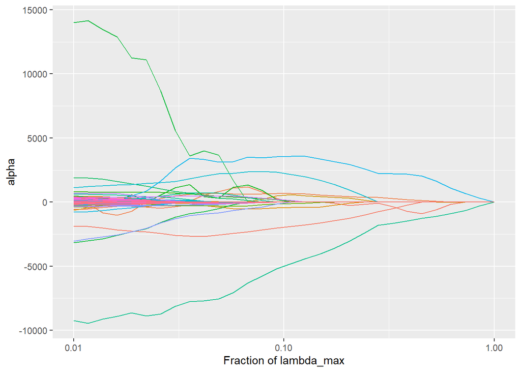

```r
# trac regularization path
plot_trac_path(fit) #default will show alpha coefficients
```

```r
# str(fit)
```

This plot, alpha vs. lambda, shows the solution path. Each line is a taxa, where the path of its “alpha coefficient” as a product of the tuning parameter increases (left to right). x-axis of these plots represent the tuning parameter

What is meant by “early on in the path?” fit == a list that is representative of the path. So the nonzero function below, takes the first non-zero alpha∂

```r
show_nonzeros <- function(x) x[x != 0]
show_nonzeros(fit[[1]]$alpha[, 2])
```

```
## Life::Bacteria::Firmicutes::Clostridia::Clostridiales::Ruminococcaceae
##                                                               306.4128
## Life::Bacteria::Firmicutes::Clostridia::Clostridiales::Lachnospiraceae
##                                                              -306.4128
```

Repeat with beta values, these are coefficients that correspond to the leaf taxa

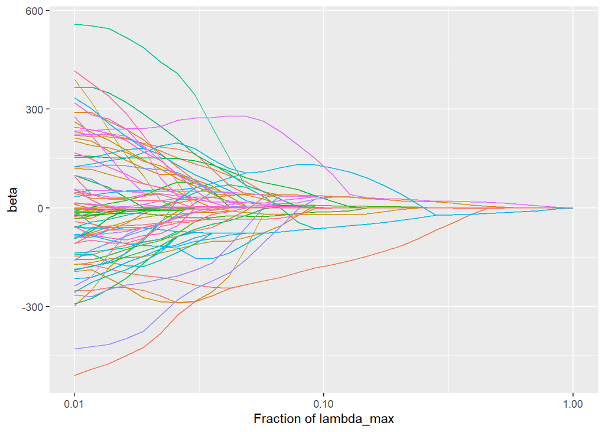

```r
plot_trac_path(fit, coef = "beta")
```

Define leaf taxa (beta) vs. nodes of the tree (alpha)?

For beta plot, as tuning parameter (amount of regularization increases), the beta coefficients (y-axis) fuse together - this is the aggregation of taxa via trac regularizer.

Therefore, we need to cross validate to choose the most appropriate tuning parameter

```r
# ?cv_trac
cvfit <- cv_trac(fit, Z = ztr, y = ytr, A = sCD14$A)
```

```
## fold 1
## fold 2
## fold 3
## fold 4
## fold 5
```

```r
# default is 5-fold cross validation
```

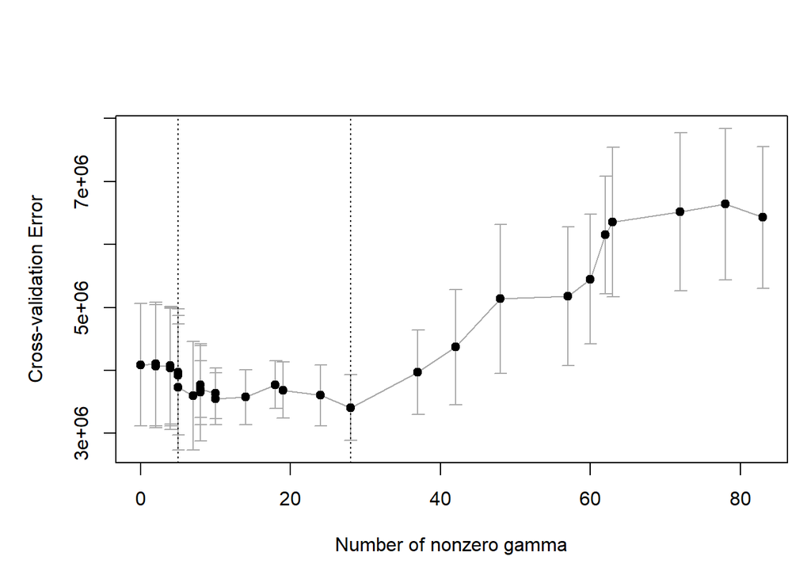

```r
plot_cv_trac(cvfit)
```

This plot shows the minimum mean squared error and one standard-error rule. Where the vertical lines are the aggregations that are selected as part of the cross-validation. - on the left (should be dashed??) is the 1SE rule - on the right (should be dotted) is the CV best

What is the value of the vertical lines?

```r
cvfit$cv[[1]]$ibest #20
```

```
## [1] 20
```

```r
cvfit$cv[[1]]$i1se #8
```

```
## [1] 8
```

What are the taxa using the 1SE rule with respect to the nonzero alpha coefficients? Structure of ‘fit’?

```r
show_nonzeros(fit[[1]]$alpha[, cvfit$cv[[1]]$i1se])
```

```
##                                                         Life::Bacteria::Actinobacteria
##                                                                              -501.4342
## Life::Bacteria::Bacteroidetes::Bacteroidia::Bacteroidales::Bacteroidaceae::Bacteroides
##                                                                               286.8039
##                 Life::Bacteria::Firmicutes::Clostridia::Clostridiales::Ruminococcaceae
##                                                                              2221.7522
##                 Life::Bacteria::Firmicutes::Clostridia::Clostridiales::Lachnospiraceae
##                                                                             -1644.8562
##                                                                         Life::Bacteria
##                                                                              -362.2657
```

Predictions

```r
# ?predict_trac
yhat_te <- predict_trac(fit, new_Z = zte)
testerr <- colMeans((yhat_te[[1]] - yte)^2)
nnz <- colSums(fit[[1]]$alpha != 0)
class(nnz)
```

```
## [1] "numeric"
```

```r
# Numeric output where I've made a predction on the test set. And then computed the mean squared error ont he test set.
```

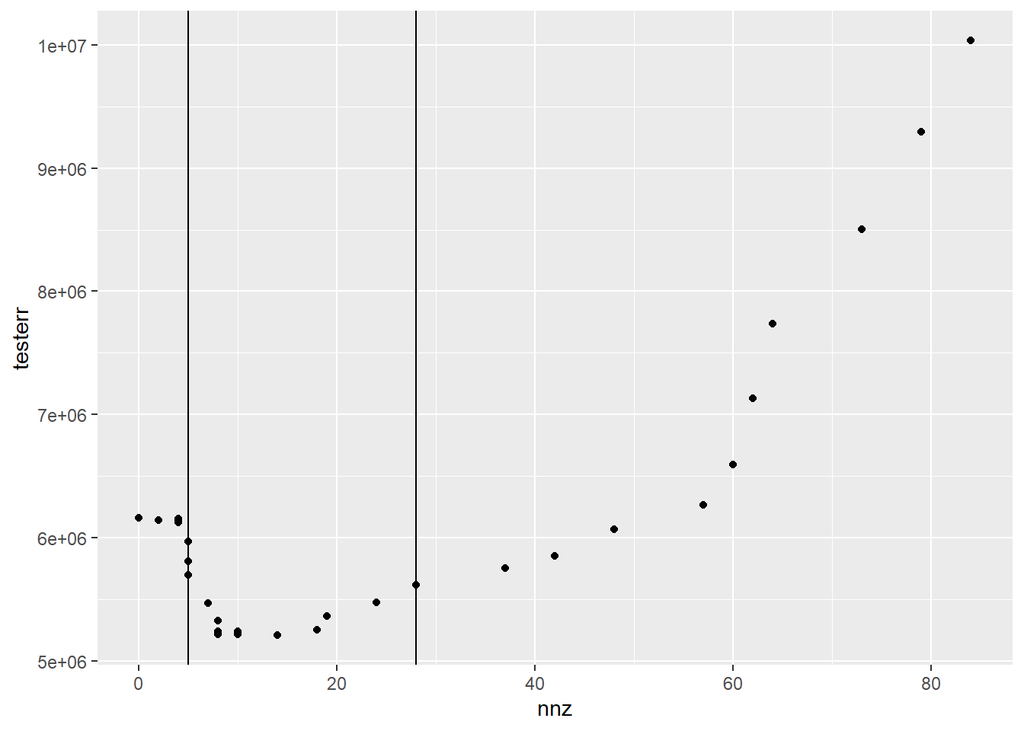

```r
tibble(nnz = nnz, testerr = testerr) %>%
  ggplot(aes(x = nnz, y = testerr)) +
  geom_point() +
  geom_vline(xintercept = nnz[cvfit$cv[[1]]$i1se]) + # or 5?
  geom_vline(xintercept = nnz[cvfit$cv[[1]]$ibest]) # 23
```

trac = 1/2

```r
fit2 <- trac(ztr, ytr, A = sCD14$A, min_frac = 1e-2,
             nlam = 30, w = Matrix::colSums(sCD14$A)^0.5)
```

Are the other 2 examples, the aggregating and the sparse log-contrast just other options? (The sparse log-contrast model is without aggregating it is only possible to do the regression analysis on one pre-specified taxonomic level. The other aggregation example of trac shows that we can nudge the penality to select on a higher or a lower level of the taxonomic tree. Here the `w` with `a = 0.5` favors selection near the otu level.) What else is a good way to interpret Figure 2E. But also write about Figure 2E? And Isolate the alpha coefficient? (Based on the selected components we can form explicit log-ratios that have a influence on the output.) # Apply to deep-sea vent data Data originates from Mid-Cayman Rise (MCR).

Input data includes raw input but also phyloseq objects.

```r
load("input-data/MCR-amplicon-data.RData", verbose = TRUE)
```

```
## Loading objects:
##   phylo_obj
##   samplenames
##   physeq_wnames
##   metadata_mcr
##   asv_wtax_qc
##   TAX
##   tax_matrix
##   physeq_mcr
```

## 2.2 Isolate MCR samples for what environmental parameters are non-NAs

> What can I do with NAs? any other ideas? such patchy data… I can expand the dataset, but my core questions rely on the samples in this example.

```r
# class(samplenames)

keep <- data.frame(samplenames) %>%
  rownames_to_column(var = "SEQ_NAME") %>%
  filter(!(SAMPLETYPE == "Incubation")) %>%
  select(SEQ_NAME)

keep_samples <- as.character(keep$SEQ_NAME)

mcr_temp_keep <- prune_samples(keep_samples, physeq_mcr)
# sample_data(mcr_temp_keep)$TEMP
# Right now, temperature data is all I have for every single sample.

# mcr_temp_keep
```

# 3 Function to generate trac inputs

See trac code for paper - https://github.com/jacobbien/trac-reproducible

Function for creating trac inputs

**Note that the “long” input doesn’t currently work! Will fix shortly.**

```r
# Function to take phyloseq object and isolate needed inputs for trac

#Should be familiar with input phyloseq taxonomic names. In cases where there are Unassigned or Unclassified, change to NAs

make_trac_input <- function(phyloseq_in, env_param, tax_short_description, tax_long_description){
  out <- genefilter_sample(
              phyloseq_in,
              filterfun_sample(function(x) x >= 1),
              A = 0.1 * nsamples(phyloseq_in))
  filtered <- prune_taxa(out, phyloseq_in)
  # Extract taxa data
  taxa <- filtered@tax_table@.Data
  total_col <- ncol(taxa)
  # Replace NAs with short version unassigned with level
  # blank_nas <- paste0(short, "__") # for troubleshooting
  blank_nas <- paste0(tax_short_description, "__")
  for (i in 1:total_col) taxa[is.na(taxa[, i]), i] <- blank_nas[i]
  #
  taxa <- cbind(taxa, rownames(taxa))
  otu_col <- total_col + 1
  colnames(taxa)[otu_col] <- "OTU"
  # make it so labels are unique
  for (i in seq(1, total_col)) {
    # add a number when the type is unknown... e.g. "g__"
    ii <- nchar(taxa[, i]) == 3
    if (sum(ii) > 0)
      taxa[ii, i] <- paste0(taxa[ii, i], 1:sum(ii))
  }
  taxa <- as.data.frame(taxa) %>%
    add_column(Rank0 = "Life") %>%
    select(Rank0, everything())
  #
  for (i in 2:ncol(taxa)) {
    taxa[, i] <- paste(taxa[, i-1], taxa[, i], sep = "::")
    }
  # convert all columns from character to factors for tax_table_to_phylo
  for (i in seq_along(taxa)) taxa[, i] <- factor(taxa[, i])
  #
  # Below command requires work
  # tree_out <- tax_table_to_phylo(~Rank0/Domain/Supergroup/Phylum/Class/Order/Family/Genus/Species/OTU, data = taxa, collapse = TRUE)
  tree_out <- tax_table_to_phylo(as.formula(tax_long_description), data = taxa, collapse = TRUE)
  ## TO DO figure out how to provide argument in tax_table_to_phylo()
  # tree_out <- tax_table_to_phylo(noquote(long), data = taxa, collapse = TRUE)
  # tree_out <- tax_table_to_phylo(paste0("~Rank0", tax_long_description), data = taxa, collapse = TRUE)
  # Generate A matrix
  A_out <- phylo_to_A(tree_out)
  # y_out <- (sample_data(filtered)$col_select)
  # y_out_num <- as.numeric(levels(y_out))[y_out]
  y_out <- as.factor(sample_data(filtered)$env_param)
  yy_out <- as.numeric(levels(y_out))[y_out]
  # rm_na <- which(is.na(y_out_num)) # Option to include an NA removal step
  data_input <- list(y = yy_out,
                     x = t(filtered@otu_table@.Data),
                     tree = tree_out,
                     tax = taxa,
                     A = A_out)
  return(data_input)
}
```

Parameters for function `make_trac_input(phyloseq_in, env_param, tax_short_description, tax_long_description)`

- phyloseq_in = phyloseq object
- env_param = column name of environmental parameter
- tax_short_description = single letter list of taxonomic levels
- tax_long_description = *pending* slash separated taxonomic levels in the same order as short

Examples of short and long

```r
#tax_long_description
long <- c("~Rank0/Domain/Supergroup/Phylum/Class/Order/Family/Genus/Species/OTU")
as.formula(long)
```

```
## ~Rank0/Domain/Supergroup/Phylum/Class/Order/Family/Genus/Species/OTU
## <environment: 0x0000019a2d1bd7d0>
```

```r
#tax_short_description
short <- c("d", "s", "p", "c", "o", "f", "g", "s")
```

Application to my own data

```r
# Use mcr_temp_keep, because we know TEMP doesn't have any NAs
trac_mcr <- make_trac_input(mcr_temp_keep, TEMP, short, long)
```

Check

```r
# trac_mcr$y # incorrect output?!?!
y <- as.factor(sample_data(mcr_temp_keep)$TEMP)
yy <- as.numeric(levels(y))[y]
yy
```

```
##  [1]   4.181   4.208 137.000 108.000 108.000  94.000 121.600  21.000   4.460
## [10]   4.460  48.000  85.000  36.000  98.200
```

```r
class(trac_mcr) # list, check all outputs below
```

```
## [1] "list"
```

```r
class(trac_mcr$y) # use yy instead
```

```
## [1] "numeric"
```

```r
# trac_mcr$y # why is output numeric(0)??
# class(trac_mcr$x)
class(trac_mcr$tree)
```

```
## [1] "phylo"
```

```r
class(trac_mcr$tax)
```

```
## [1] "data.frame"
```

```r
class(trac_mcr$A)
```

```
## [1] "dgCMatrix"
## attr(,"package")
## [1] "Matrix"
```

```r
class(trac_mcr$y)
```

```
## [1] "numeric"
```

Apply vignette to temp and OTU data from MCR.

```r
set.seed(123)

# use yy instead of trac_mcr$y

ntot <- length(yy)
ntot
```

```
## [1] 14
```

```r
n <- round(2/3 * ntot)
n
```

```
## [1] 9
```

```r
tr <- sample(ntot, n)

# log of feature matrix
log_pseudo <- function(x, pseudo_count = 1) log(x + pseudo_count)
# ytr <- trac_mcr$y[tr]
# yte <- trac_mcr$y[-tr]
ytr <- yy[tr]
yte <- yy[-tr]
ztr <- log_pseudo(trac_mcr$x[tr, ])
zte <- log_pseudo(trac_mcr$x[-tr, ])
zmcr <- log_pseudo(trac_mcr$x)
dim(ztr); dim(zte)
```

```
## [1]    9 1633
```

```
## [1]    5 1633
```

```r
fit <- trac(ztr, ytr, A = trac_mcr$A, min_frac = 1e-2, nlam = 30)

fit_mcr <- trac(zmcr, yy, A = trac_mcr$A, min_frac = 1e-2, nlam = 30)
```

## 3.1 trac output with MCR data

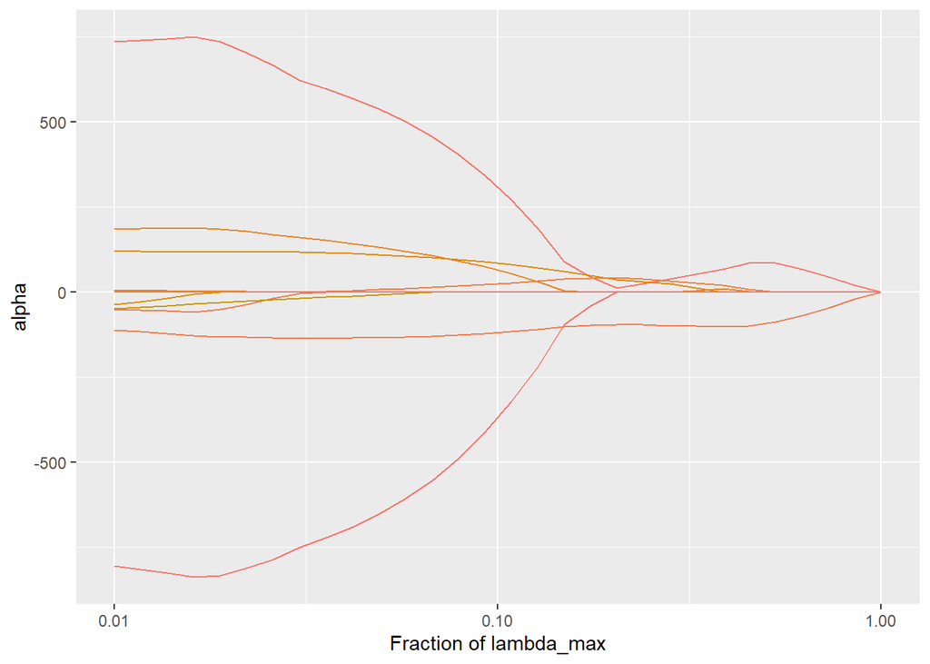

```r
plot_trac_path(fit)
```

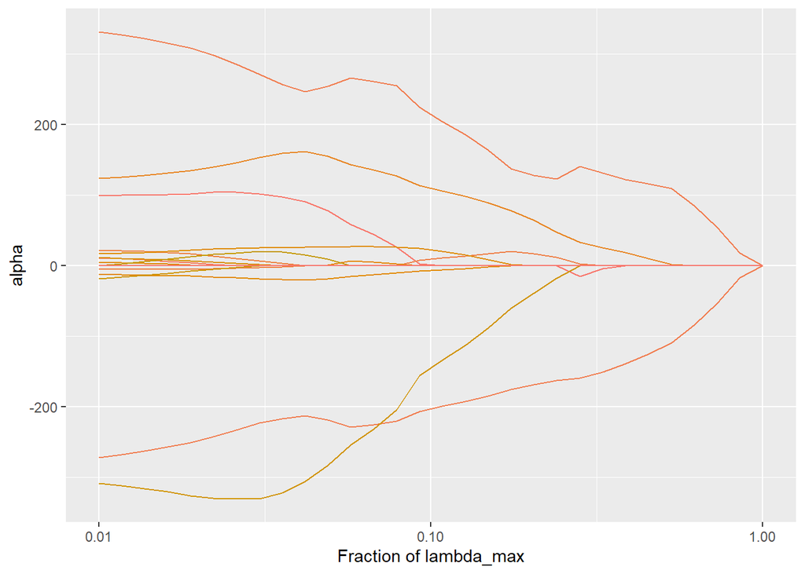

```r
plot_trac_path(fit_mcr)
```

```r
show_nonzeros <- function(x) x[x != 0]

show_nonzeros(fit[[1]]$alpha[, 2])
```

```
## 'Life::Eukaryota::Alveolata::Dinoflagellata::Dinophyceae'
##                                                  -20.2992
##                              'Life::Eukaryota::Alveolata'
##                                                   20.2992
```

```r
show_nonzeros(fit_mcr[[1]]$alpha[, 2])
```

```
## 'Life::Eukaryota::Alveolata::Dinoflagellata::Dinophyceae'
##                                                  -17.2023
##              'Life::Eukaryota::Alveolata::Dinoflagellata'
##                                                   17.2023
```

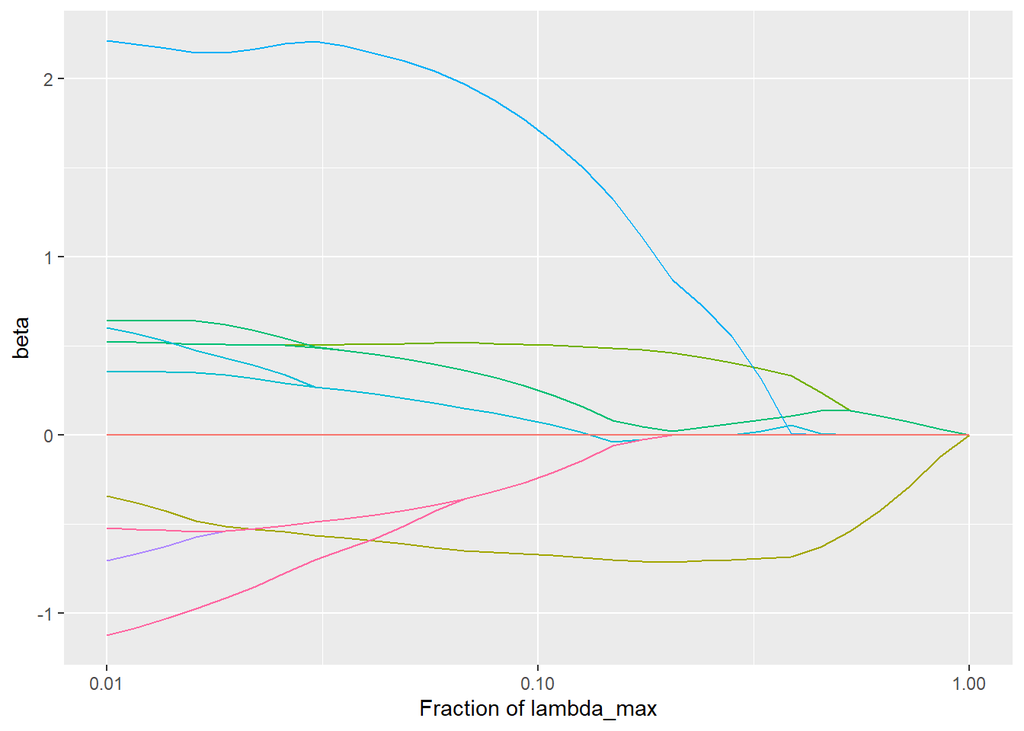

```r
plot_trac_path(fit, coef = "beta")
```

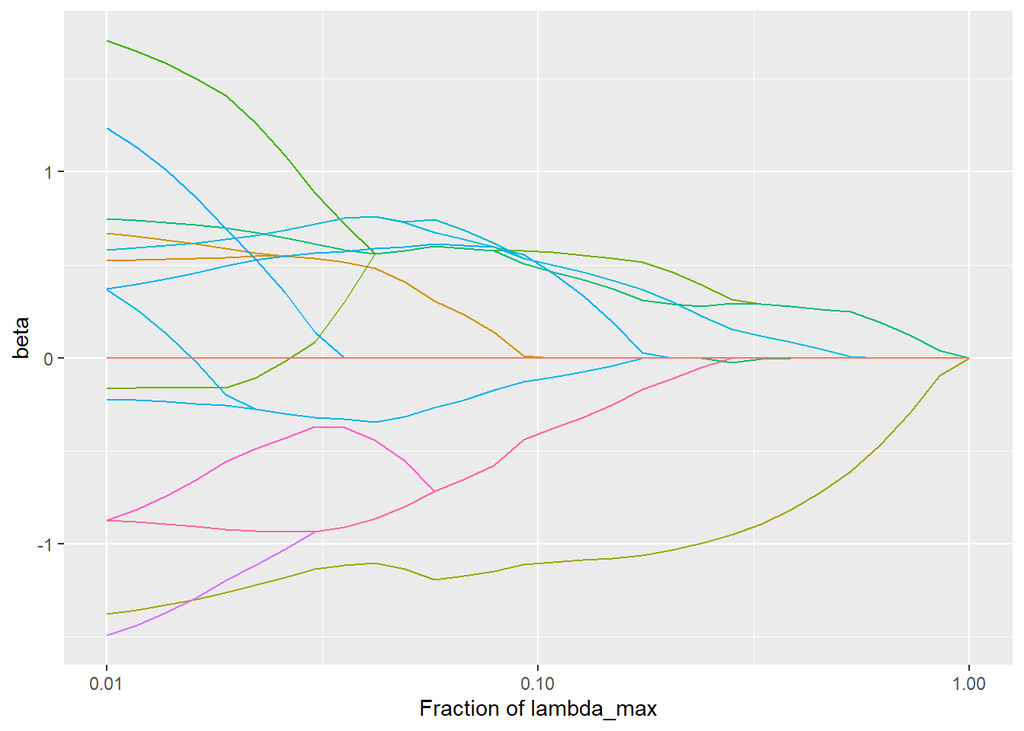

```r
plot_trac_path(fit_mcr, coef = "beta")
```

```r
cvfit <- cv_trac(fit, Z = ztr, y = ytr, A = trac_mcr$A)
```

```
## fold 1
## fold 2
## fold 3
## fold 4
## fold 5
```

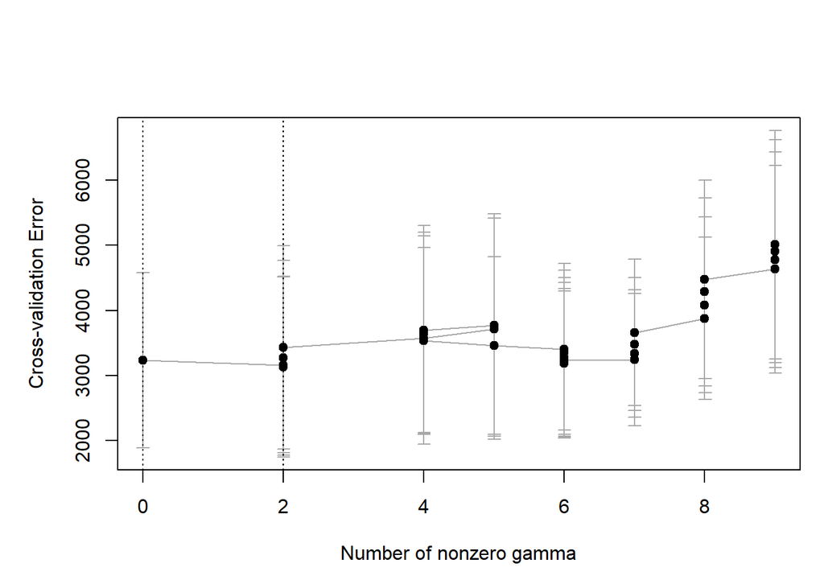

```r
plot_cv_trac(cvfit)
```

```r
cvfit_mcr <- cv_trac(fit_mcr, Z = ztr, y = ytr, A = trac_mcr$A)
```

```
## fold 1
## fold 2
## fold 3
## fold 4
## fold 5
```

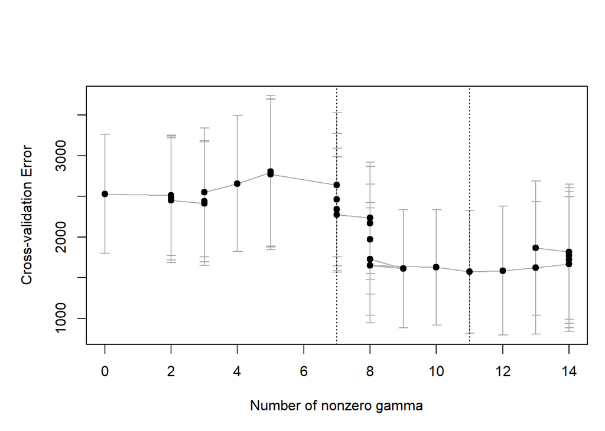

```r
plot_cv_trac(cvfit_mcr)
```

```r
cvfit$cv[[1]]$ibest
```

```
## [1] 3
```

```r
cvfit$cv[[1]]$i1se
```

```
## [1] 1
```

```r
# 3, 1
```

```r
# show_nonzeros(fit[[1]]$alpha[, cvfit$cv[[1]]$i1se])
```